# COVID-19 US Confirmed Cases and Deaths Data Analysis

2023-12-03

## Overview

This report is an analysis of multiple COVID data sets available from John’s Hopkins github page. The data sets are as follows:

- [US Confirmed Cases](https://raw.githubusercontent.com/CSSEGISandData/COVID-19/master/csse_covid_19_data/csse_covid_19_time_series/time_series_covid19_confirmed_US.csv): Time series data of confirmed COVID-19 cases in the US.
- [US Deaths](https://raw.githubusercontent.com/CSSEGISandData/COVID-19/master/csse_covid_19_data/csse_covid_19_time_series/time_series_covid19_deaths_US.csv): Time series data of COVID-19-related deaths in the US.

I will retrieve population data for each US state:

I will create variables for the **US Confirmed Cases** and **US Deaths** datasets:

```r
# US Confirmed cases
us_confirmed <- read.csv("https://raw.githubusercontent.com/CSSEGISandData/COVID-19/master/csse_covid_19_data/csse_covid_19_time_series/time_series_covid19_confirmed_US.csv")

# US Deaths
us_deaths <- read.csv("https://raw.githubusercontent.com/CSSEGISandData/COVID-19/master/csse_covid_19_data/csse_covid_19_time_series/time_series_covid19_deaths_US.csv")

usStatePop <- read.csv('https://raw.githubusercontent.com/ColoradoGus/DTSA5301/main/NST-EST2022-POPCHG2020_2022.csv')
usStatePop <- select(usStatePop, NAME, POPESTIMATE2022)
```

Using this data set, I will do some high-level analysis of the data set. First, I’m going to focus on US confirmed COVID-19 cases by analyzing the dataframe called **us_confirmed**.

## US Confirmed Cases Analysis

### DataFrame Overview

```r
# head of us_confirmed
head(us_confirmed[, c("Lat", "Long_", "Province_State", "X3.9.23")])
```

```
##        Lat     Long_ Province_State X3.9.23
## 1 32.53953 -86.64408        Alabama   19790
## 2 30.72775 -87.72207        Alabama   69860
## 3 31.86826 -85.38713        Alabama    7485
## 4 32.99642 -87.12511        Alabama    8091
## 5 33.98211 -86.56791        Alabama   18704
## 6 32.10031 -85.71266        Alabama    3030
```

### Creating Daily Cases Total DataFrame

Let’s look at daily confirmed cases as a line chart. First we need to create daily totals of cases by date.

```r
# Sum the cases for each date
daily_totals <- colSums(us_confirmed[, 12:(ncol(us_confirmed))])

# Convert the date fields
dates <- sub("^X", "", names(daily_totals))
formatted_dates <- as.Date(dates, format = "%m.%d.%y")

# Create the dataframe for plotting daily totals
daily_data <- data.frame(
  Date = formatted_dates,
  Cases = as.numeric(daily_totals)
)

head(daily_data)
```

```
##         Date Cases
## 1 2020-01-22     1
## 2 2020-01-23     1
## 3 2020-01-24     2
## 4 2020-01-25     2
## 5 2020-01-26     5
## 6 2020-01-27     5
```

### Plotting Daily Totals

Cumulative confirmed cases reached a total of 103,802,702 cases. Remember, people can get COVID-19 multiple times. It is hard to know how many unique people had COVID-19.

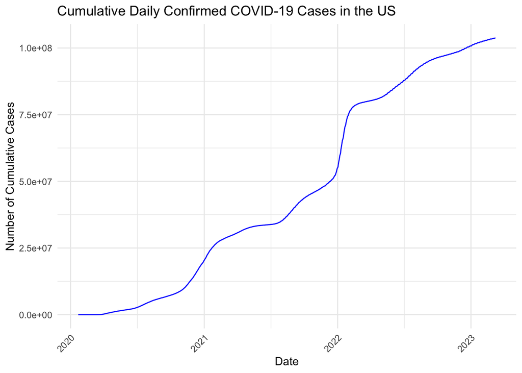

```r
ggplot(daily_data, aes(x = Date, y = Cases)) +
  geom_line(color = "blue") +
  labs(title = "Cumulative Daily Confirmed COVID-19 Cases in the US",
       x = "Date",
       y = "Number of Cumulative Cases") +
  theme_minimal() +
  theme(axis.text.x = element_text(angle = 45, hjust = 1))
```

The graph makes it clear that COVID cases spiked in the winter.

## US Confirmed Deaths

### Reviewing Confirmed Deaths DataFrame

Now I’d like to look at confirmed deaths. There are 1,123,836 confirmed deaths in the data set.

```r
# The head of the us_deaths dataset.
head(us_deaths[, c("Lat", "Long_", "Province_State", "X3.9.23")])
```

```
##        Lat     Long_ Province_State X3.9.23
## 1 32.53953 -86.64408        Alabama     232
## 2 30.72775 -87.72207        Alabama     727
## 3 31.86826 -85.38713        Alabama     103
## 4 32.99642 -87.12511        Alabama     109
## 5 33.98211 -86.56791        Alabama     261
## 6 32.10031 -85.71266        Alabama      54
```

### Creating a Cumulative Daily COVID Deaths DataFrame

In order to plot the cumulative daily deaths, I want to create a new dataframe with one row per date and the cumulative deaths for that date. The tail of the dataframe is shown below.

```r
# Sum the cases for each date
daily_death_totals <- colSums(us_deaths[, 13:(ncol(us_deaths))])

# Convert the data into a format suitable for ggplot2
dates <- sub("^X", "", names(daily_death_totals))
formatted_dates <- as.Date(dates, format = "%m.%d.%y")

# Create the dataframe for plotting
daily_death_data <- data.frame(
  Date = formatted_dates,
  Cases = as.numeric(daily_death_totals)
)

tail(daily_death_totals)
```

```
## X3.4.23 X3.5.23 X3.6.23 X3.7.23 X3.8.23 X3.9.23
## 1122172 1122134 1122181 1122516 1123246 1123836
```

### Plotting Daily Deaths

I will plot cumulative daily confirmed deaths, in the same way I plotted daily confirmed cases.

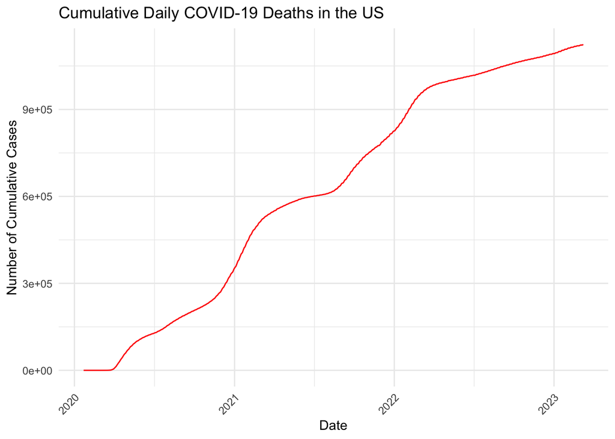

```r
ggplot(daily_death_data, aes(x = Date, y = Cases)) +
  geom_line(color = "red") +
  labs(title = "Cumulative Daily COVID-19 Deaths in the US",
       x = "Date",
       y = "Number of Cumulative Cases") +
  theme_minimal() +
  theme(axis.text.x = element_text(angle = 45, hjust = 1))
```

## Visualizing Cases and Deaths in a Single Plot

I want to visualize cases and deaths in the same plot. First, I will create a merged dataframe of cases and deaths.

### Creating a Merged DataFrame

I will create a merged dataframe and calculate the log of each column as well.

```r
# Sum the cases for each date
mergedDailyData = merge(daily_data, daily_death_data, by="Date")
names(mergedDailyData)[names(mergedDailyData) == "Cases.y"] <- "Deaths"
names(mergedDailyData)[names(mergedDailyData) == "Cases.x"] <- "Cases"

mergedDailyData$logCases = log(mergedDailyData$Cases, base = 10)
mergedDailyData$logDeaths = log(mergedDailyData$Deaths, base = 10)
mergedDailyData$deathsPerCase = mergedDailyData$Deaths/mergedDailyData$Cases
last_value <- round(tail(mergedDailyData$deathsPerCase, 1),2)

head(mergedDailyData)
```

```
##         Date Cases Deaths logCases logDeaths deathsPerCase
## 1 2020-01-22     1      1  0.00000         0           1.0
## 2 2020-01-23     1      1  0.00000         0           1.0
## 3 2020-01-24     2      1  0.30103         0           0.5
## 4 2020-01-25     2      1  0.30103         0           0.5
## 5 2020-01-26     5      1  0.69897         0           0.2
## 6 2020-01-27     5      1  0.69897         0           0.2
```

### Plotting the Log10 of Confirmed Cases and Deaths

Since the scale of cases and deaths differ by two orders of magnitude, I want to plot the cases and deaths on a log scale. In this plot, we can better see a comparision between the Cumulative cases and Deaths over time.

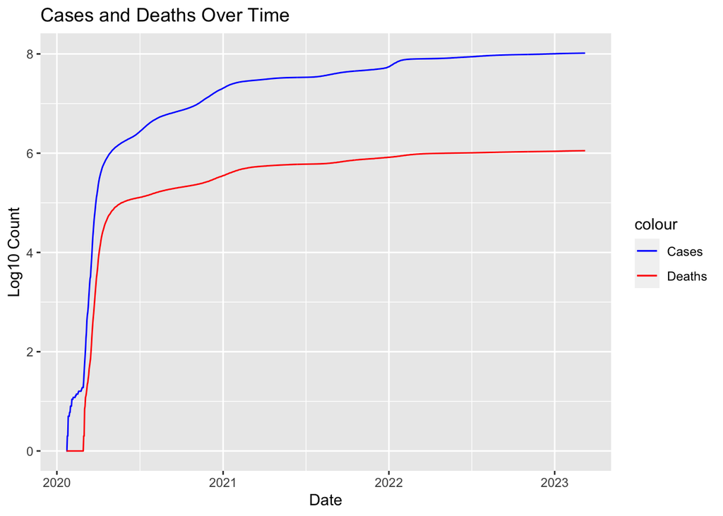

```r
ggplot(mergedDailyData, aes(x = Date)) +
  geom_line(aes(y = logCases, color = "Cases")) +
  geom_line(aes(y = logDeaths, color = "Deaths")) +
  labs(title = "Cases and Deaths Over Time", x = "Date", y = "Log10 Count") +
  scale_color_manual(values = c("Cases" = "blue", "Deaths" = "red"))
```

## Modeling and Visualizing Case Fatality Rate

In the merged DataFrame I created, I calculated the fatality rate. The case fatality rate appears to be around 0.01. I’d like to visualize the case fatality rate over the data’s date range.

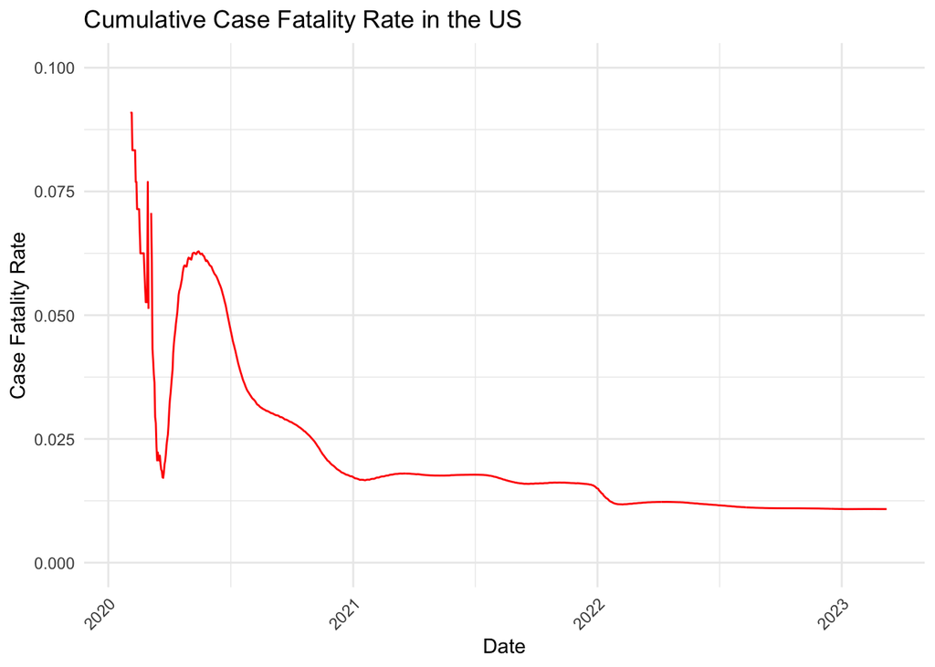

```r
ggplot(mergedDailyData, aes(x = Date, y = deathsPerCase)) +
  geom_line(color = "red") +
  labs(title = "Cumulative Case Fatality Rate in the US",
       x = "Date",
       y = "Case Fatality Rate") +
  theme_minimal() +
  theme(axis.text.x = element_text(angle = 45, hjust = 1)) +
  ylim(0, 0.1)
```

## Modeling and Visualizing Per Capita Deaths By State

I’d like to model and visualize deaths per capita by state. I’ll first create a dataframe with total deaths per state.

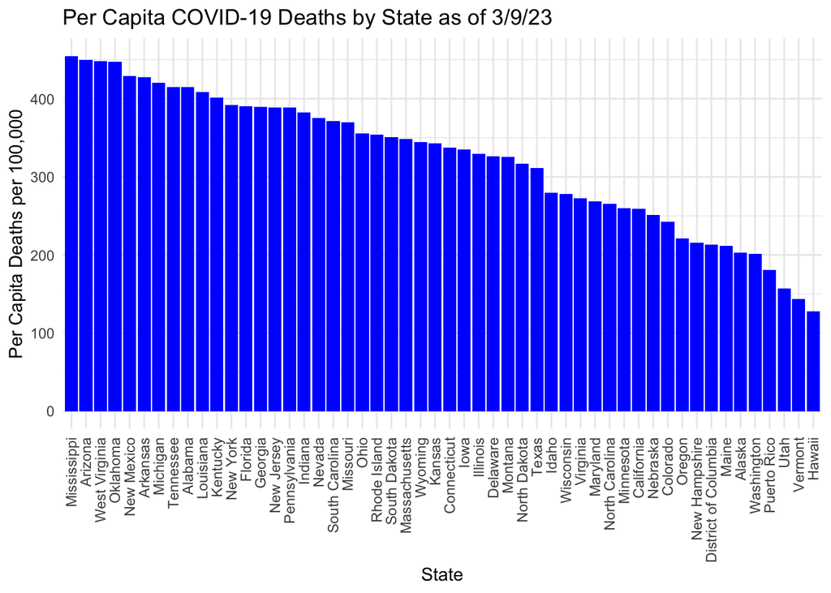

```r
selected_data <- us_deaths %>% select(Province_State, `X3.9.23`)
total_cases_by_state <- (selected_data %>%
                        group_by(Province_State) %>%
                        summarise(Total_Cases = sum(`X3.9.23`, na.rm = TRUE)))

merged_data <- merge(total_cases_by_state, usStatePop, by.x = 'Province_State', by.y = 'NAME')

merged_data$per_capita_total = merged_data$Total_Cases/merged_data$POPESTIMATE2022 *100000

# Arranging the data by per capita deaths in descending order for all states
all_states_per_capita_deaths <- merged_data %>%
  arrange(desc(per_capita_total))

# Plotting the bar chart
ggplot(all_states_per_capita_deaths, aes(x = reorder(Province_State, -per_capita_total), y = per_capita_total)) +
  geom_bar(stat = "identity", fill = "blue") +
  labs(title = "Per Capita COVID-19 Deaths by State as of 3/9/23",
       x = "State",
       y = "Per Capita Deaths per 100,000") +
  theme_minimal() +
  theme(axis.text.x = element_text(angle = 90, vjust = 0.5, hjust=1))
```

Looking at the bar chart, I’m curious if there is a correlation with political affiliation of the state (Republican / Democrat) and the death rate. I’ll save that for another analysis.

## Conclusion and Biases

### Overall

To summarize, I analyzed the US Covid Confirmed Cases and Confirmed Deaths data sets. I visualized the log Case and Death totals and modeled the case fatality rate. I also modeled the total deaths per capita by state. Overall, this was an interesting data set on which to perform basic analysis. Also, it highlights how the modern world can track so much health informaton. This data set is just the tip of the iceberg!

### Biases

There can be a number of biases in the data sets. For deaths, it is possible that Covid could be over-attributed to the cause of death. However it is possible early on that the cases were under reported before testing was widely performed. Additionally, it can be hard to interpret the case fatality rate because the vaccine became available during this time interval.